# SED610 Lab Test #1

### Test Date : 25 Oct 2020 Duration : 1 hour 30 mins

### Questions : 40 points ( 2 points/question )

### In each question, please write your python code in the space provided.

**Student ID :** (Type below)

```python
64130701719
```

```
64130701719
```

**Student Name :** (Type below)

```python
"Kanyawee Sadubjit"
```

```
'Kanyawee Sadubjit'
```

### Q1. Import python packages here

```python
import numpy as np
import pandas as pd
import matplotlib.pyplot as plt
from matplotlib.pyplot import pie, axis, show

import seaborn as sns
%matplotlib inline
```

### Q2. Read in the csv file **'WHO-COVID-19-global-data.csv'** as a data frame called covid.

```python
df = pd.read_csv("WHO-COVID-19-global-data.csv")
```

### Q3. View the data structure of the covid

```python
df.head()
```

|  | Date_reported | Country_code | Country | WHO_region | New_cases | Cumulative_cases | New_deaths | Cumulative_deaths |
| --- | --- | --- | --- | --- | --- | --- | --- | --- |
| 0 | 2020-01-03 | AF | Afghanistan | EMRO | 0 | 0 | 0 | 0 |
| 1 | 2020-01-04 | AF | Afghanistan | EMRO | 0 | 0 | 0 | 0 |
| 2 | 2020-01-05 | AF | Afghanistan | EMRO | 0 | 0 | 0 | 0 |
| 3 | 2020-01-06 | AF | Afghanistan | EMRO | 0 | 0 | 0 | 0 |
| 4 | 2020-01-07 | AF | Afghanistan | EMRO | 0 | 0 | 0 | 0 |

```python
df.info()
```

```
<class 'pandas.core.frame.DataFrame'>
RangeIndex: 69090 entries, 0 to 69089
Data columns (total 8 columns):
 #   Column             Non-Null Count  Dtype
---  ------             --------------  -----
 0   Date_reported      69090 non-null  object
 1   Country_code       68796 non-null  object
 2   Country            69090 non-null  object
 3   WHO_region         69090 non-null  object
 4   New_cases          69090 non-null  int64
 5   Cumulative_cases   69090 non-null  int64
 6   New_deaths         69090 non-null  int64
 7   Cumulative_deaths  69090 non-null  int64
dtypes: int64(4), object(4)
memory usage: 4.2+ MB
```

### Q4. View the top 10 rows of data in the covid

```python
df.head(10)
```

|  | Date_reported | Country_code | Country | WHO_region | New_cases | Cumulative_cases | New_deaths | Cumulative_deaths |
| --- | --- | --- | --- | --- | --- | --- | --- | --- |
| 0 | 2020-01-03 | AF | Afghanistan | EMRO | 0 | 0 | 0 | 0 |
| 1 | 2020-01-04 | AF | Afghanistan | EMRO | 0 | 0 | 0 | 0 |
| 2 | 2020-01-05 | AF | Afghanistan | EMRO | 0 | 0 | 0 | 0 |
| 3 | 2020-01-06 | AF | Afghanistan | EMRO | 0 | 0 | 0 | 0 |
| 4 | 2020-01-07 | AF | Afghanistan | EMRO | 0 | 0 | 0 | 0 |
| 5 | 2020-01-08 | AF | Afghanistan | EMRO | 0 | 0 | 0 | 0 |
| 6 | 2020-01-09 | AF | Afghanistan | EMRO | 0 | 0 | 0 | 0 |
| 7 | 2020-01-10 | AF | Afghanistan | EMRO | 0 | 0 | 0 | 0 |
| 8 | 2020-01-11 | AF | Afghanistan | EMRO | 0 | 0 | 0 | 0 |
| 9 | 2020-01-12 | AF | Afghanistan | EMRO | 0 | 0 | 0 | 0 |

### Q5. Create a new column called 'Report_date' that is coverted from the column 'Date_reported' with string type to DateTime object.

```python
df['Report_date'] = df['Date_reported'].astype('string')
```

```python
#sea type data column 8 Report_date is string
df.info()
```

```
<class 'pandas.core.frame.DataFrame'>
RangeIndex: 69090 entries, 0 to 69089
Data columns (total 9 columns):
 #   Column             Non-Null Count  Dtype
---  ------             --------------  -----
 0   Date_reported      69090 non-null  object
 1   Country_code       68796 non-null  object
 2   Country            69090 non-null  object
 3   WHO_region         69090 non-null  object
 4   New_cases          69090 non-null  int64
 5   Cumulative_cases   69090 non-null  int64
 6   New_deaths         69090 non-null  int64
 7   Cumulative_deaths  69090 non-null  int64
 8   Report_date        69090 non-null  string
dtypes: int64(4), object(4), string(1)
memory usage: 4.7+ MB
```

### Q6. Create a new column called 'Month'. The 'Month' column can be created based off of the DateTime object of Report_date column.

```python
df['Month'] = df['Report_date'].str.split('-').str[1]
```

```python
#sea type data column 9 Month
df.tail()
df.info()
```

```
<class 'pandas.core.frame.DataFrame'>
RangeIndex: 69090 entries, 0 to 69089
Data columns (total 10 columns):
 #   Column             Non-Null Count  Dtype
---  ------             --------------  -----
 0   Date_reported      69090 non-null  object
 1   Country_code       68796 non-null  object
 2   Country            69090 non-null  object
 3   WHO_region         69090 non-null  object
 4   New_cases          69090 non-null  int64
 5   Cumulative_cases   69090 non-null  int64
 6   New_deaths         69090 non-null  int64
 7   Cumulative_deaths  69090 non-null  int64
 8   Report_date        69090 non-null  string
 9   Month              69090 non-null  object
dtypes: int64(4), object(5), string(1)
memory usage: 5.3+ MB
```

### Q7. Show Country code, Country name and Region (remove all duplicate rows)

```python
df[['Country_code','Country','WHO_region']].drop_duplicates()
```

|  | Country_code | Country | WHO_region |
| --- | --- | --- | --- |
| 0 | AF | Afghanistan | EMRO |
| 294 | AL | Albania | EURO |
| 588 | DZ | Algeria | AFRO |
| 882 | AS | American Samoa | WPRO |
| 1176 | AD | Andorra | EURO |
| ... | ... | ... | ... |
| 67620 | VN | Viet Nam | WPRO |
| 67914 | WF | Wallis and Futuna | WPRO |
| 68208 | YE | Yemen | EMRO |
| 68502 | ZM | Zambia | AFRO |
| 68796 | ZW | Zimbabwe | AFRO |

235 rows × 3 columns

[output not shown]

### Q8. View the country name (only distinct value)

*Show the result in Panda Series, not jus Python array.*

```python
pd.Series(df['Country'].unique())
```

```
0            Afghanistan
1                Albania
2                Algeria
3         American Samoa
4                Andorra
             ...
230             Viet Nam
231    Wallis and Futuna
232                Yemen
233               Zambia
234             Zimbabwe
Length: 235, dtype: object
```

### Q9. How many the country name (only distinct value) are there?

*Show python code, not answer in number.*

```python
print(df['Country'].unique())
print("The country name: ", len(df['Country'].unique()),"countries")
```

```
['Afghanistan' 'Albania' 'Algeria' 'American Samoa' 'Andorra' 'Angola'
 'Anguilla' 'Antigua and Barbuda' 'Argentina' 'Armenia' 'Aruba'
 'Australia' 'Austria' 'Azerbaijan' 'Bahamas' 'Bahrain' 'Bangladesh'
 'Barbados' 'Belarus' 'Belgium' 'Belize' 'Benin' 'Bermuda' 'Bhutan'
 'Bolivia (Plurinational State of)' 'Bonaire, Sint Eustatius and Saba'
 'Bosnia and Herzegovina' 'Botswana' 'Brazil' 'British Virgin Islands'
 'Brunei Darussalam' 'Bulgaria' 'Burkina Faso' 'Burundi' 'Cabo Verde'
 'Cambodia' 'Cameroon' 'Canada' 'Cayman Islands'
 'Central African Republic' 'Chad' 'Chile' 'China' 'Colombia' 'Comoros'
 'Congo' 'Cook Islands' 'Costa Rica' 'Côte d’Ivoire' 'Croatia' 'Cuba'
 'Curaçao' 'Cyprus' 'Czechia' "Democratic People's Republic of Korea"
 'Democratic Republic of the Congo' 'Denmark' 'Djibouti' 'Dominica'
 'Dominican Republic' 'Ecuador' 'Egypt' 'El Salvador' 'Equatorial Guinea'
 'Eritrea' 'Estonia' 'Eswatini' 'Ethiopia' 'Falkland Islands (Malvinas)'
 'Faroe Islands' 'Fiji' 'Finland' 'France' 'French Guiana'
 'French Polynesia' 'Gabon' 'Gambia' 'Georgia' 'Germany' 'Ghana'
 'Gibraltar' 'Greece' 'Greenland' 'Grenada' 'Guadeloupe' 'Guam'
 'Guatemala' 'Guernsey' 'Guinea' 'Guinea-Bissau' 'Guyana' 'Haiti'
 'Holy See' 'Honduras' 'Hungary' 'Iceland' 'India' 'Indonesia'
 'Iran (Islamic Republic of)' 'Iraq' 'Ireland' 'Isle of Man' 'Israel'
 'Italy' 'Jamaica' 'Japan' 'Jersey' 'Jordan' 'Kazakhstan' 'Kenya'
 'Kiribati' 'Kosovo[1]' 'Kuwait' 'Kyrgyzstan'
 "Lao People's Democratic Republic" 'Latvia' 'Lebanon' 'Lesotho' 'Liberia'
 'Libya' 'Liechtenstein' 'Lithuania' 'Luxembourg' 'Madagascar' 'Malawi'
 'Malaysia' 'Maldives' 'Mali' 'Malta' 'Marshall Islands' 'Martinique'
 'Mauritania' 'Mauritius' 'Mayotte' 'Mexico'
 'Micronesia (Federated States of)' 'Monaco' 'Mongolia' 'Montenegro'
 'Montserrat' 'Morocco' 'Mozambique' 'Myanmar' 'Namibia' 'Nauru' 'Nepal'
 'Netherlands' 'New Caledonia' 'New Zealand' 'Nicaragua' 'Niger' 'Nigeria'
 'Niue' 'North Macedonia' 'Northern Mariana Islands (Commonwealth of the)'
 'Norway' 'occupied Palestinian territory, including east Jerusalem'
 'Oman' 'Other' 'Pakistan' 'Palau' 'Panama' 'Papua New Guinea' 'Paraguay'
 'Peru' 'Philippines' 'Pitcairn Islands' 'Poland' 'Portugal' 'Puerto Rico'
 'Qatar' 'Republic of Korea' 'Republic of Moldova' 'Réunion' 'Romania'
 'Russian Federation' 'Rwanda' 'Saint Barthélemy' 'Saint Helena'
 'Saint Kitts and Nevis' 'Saint Lucia' 'Saint Martin'
 'Saint Pierre and Miquelon' 'Saint Vincent and the Grenadines' 'Samoa'
 'San Marino' 'Sao Tome and Principe' 'Saudi Arabia' 'Senegal' 'Serbia'
 'Seychelles' 'Sierra Leone' 'Singapore' 'Sint Maarten' 'Slovakia'
 'Slovenia' 'Solomon Islands' 'Somalia' 'South Africa' 'South Sudan'
 'Spain' 'Sri Lanka' 'Sudan' 'Suriname' 'Sweden' 'Switzerland'
 'Syrian Arab Republic' 'Tajikistan' 'Thailand' 'The United Kingdom'
 'Timor-Leste' 'Togo' 'Tokelau' 'Tonga' 'Trinidad and Tobago' 'Tunisia'
 'Turkey' 'Turkmenistan' 'Turks and Caicos Islands' 'Tuvalu' 'Uganda'
 'Ukraine' 'United Arab Emirates' 'United Republic of Tanzania'
 'United States of America' 'United States Virgin Islands' 'Uruguay'
 'Uzbekistan' 'Vanuatu' 'Venezuela (Bolivarian Republic of)' 'Viet Nam'
 'Wallis and Futuna' 'Yemen' 'Zambia' 'Zimbabwe']
The country name:  235 countries
```

### Q10. What is the covid data (row) of Thailand on 1 October 2020?

```python
th_data = df[df['Country']=='Thailand']
```

```python
th_data[th_data['Report_date']=='2020-10-01']
```

|  | Date_reported | Country_code | Country | WHO_region | New_cases | Cumulative_cases | New_deaths | Cumulative_deaths | Report_date | Month |
| --- | --- | --- | --- | --- | --- | --- | --- | --- | --- | --- |
| 61424 | 2020-10-01 | TH | Thailand | SEARO | 5 | 3569 | 0 | 59 | 2020-10-01 | 10 |

### Q11. What is the maximum number of the new cases (per day) in Thailand?

```python
th_data['New_cases'].max()
```

```
252
```

### Q12. Count the days that Thailand has no new case (New_case = 0) ?

*Show python code and return only a number.*

```python
th_data[th_data['New_cases']==0].value_counts()
# function
def new_case_zero(case_zero):
    if case_zero == 0:
        return True
    else:
        return False
```

```python
# Thailand that New_cases == 0 are 70 days
th_data['New_cases'].apply(new_case_zero).value_counts()
```

```
False    224
True      70
Name: New_cases, dtype: int64
```

```python
sum(th_data['New_cases'].apply(new_case_zero))
```

```
70
```

### Q13. What is the reported date that Thailand has the maximum number of the new cases (per day)?

*Igore any warning message*

```python
# Thailand has the maximum number of the new cases: 252 (per day)
max_newcases = th_data['New_cases'].max()
max_newcases
```

```
252
```

```python
th_data[th_data['New_cases']== max_newcases]['Report_date']
```

```
61238    2020-03-29
Name: Report_date, dtype: string
```

### Q14. What is the average new deaths per day in Thailand?

```python
th_data['New_deaths'].mean()
```

```
0.20068027210884354
```

### Q15. What are the total number of new cases and the total number of new deaths in Thailand?

```python
print("The total number of new cases:",th_data['New_cases'].sum())
print("The total number of new deaths:",th_data['New_deaths'].sum())
```

```
The total number of new cases: 3719
The total number of new deaths: 59
```

### Q16. What are the top 10 affected countries?

#### Show the result in bar chart.

#### Set the title to 'Top 10 Covid affected by counrties'

```python
data = pd.DataFrame(df, columns=['Cumulative_cases', 'Country'])
data_sorted = data.sort_values(by='Cumulative_cases', ascending=False)
data_sorted
```

|  | Cumulative_cases | Country |
| --- | --- | --- |
| 66149 | 8184788 | United States of America |
| 66148 | 8124633 | United States of America |
| 66147 | 8065615 | United States of America |
| 66146 | 8019237 | United States of America |
| 66145 | 7966729 | United States of America |
| ... | ... | ... |
| 55885 | 0 | Seychelles |
| 55884 | 0 | Seychelles |
| 55883 | 0 | Seychelles |
| 55882 | 0 | Seychelles |
| 0 | 0 | Afghanistan |

69090 rows × 2 columns

```python
# ranking = data_sorted
ranking = data_sorted.groupby('Country')['Cumulative_cases'].max().sort_values().tail(10)
top10 = ranking.sort_values(ascending=False)
top10
```

```
Country
United States of America    8184788
India                       7706946
Brazil                      5273954
Russian Federation          1463306
Argentina                   1021397
Spain                       1005295
Colombia                     974139
France                       927193
Peru                         874118
Mexico                       860714
Name: Cumulative_cases, dtype: int64
```

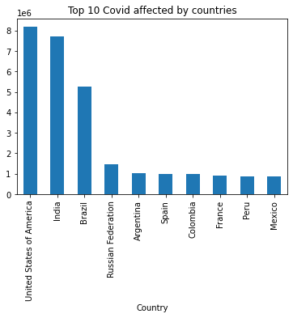

```python
top10.plot(kind='bar', title = 'Top 10 Covid affected by countries', legend=None)
```

[figure not shown]

### Q17. Show the cumulative new cases in Thailand by month?

#### Show the result in line chart.

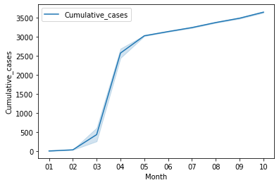

```python
sns.lineplot(data=th_data, x='Month', y='Cumulative_cases', label='Cumulative_cases')
```

[figure not shown]

### Q18. Show the total new cases by region in pie chart

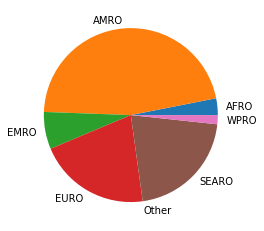

```python
sums = df.groupby(df["WHO_region"])["New_cases"].sum()
pie(sums, labels=sums.index);
show()
```

[figure not shown]

### Q.19 Show the New cases by month in Thailand

#### Show the result in box plot.

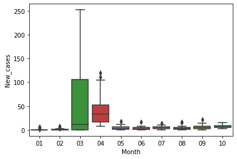

```python
sns.boxplot(x='Month', y='New_cases', data=th_data)
```

[figure not shown]

### Q20. Only Southeast Asia (SEARO), show the total new cases by month and by country by using HeatMap

```python
asia_data = df[df['WHO_region']=='SEARO']
asia_data
```

|  | Date_reported | Country_code | Country | WHO_region | New_cases | Cumulative_cases | New_deaths | Cumulative_deaths | Report_date | Month |
| --- | --- | --- | --- | --- | --- | --- | --- | --- | --- | --- |
| 4704 | 2020-01-03 | BD | Bangladesh | SEARO | 0 | 0 | 0 | 0 | 2020-01-03 | 01 |
| 4705 | 2020-01-04 | BD | Bangladesh | SEARO | 0 | 0 | 0 | 0 | 2020-01-04 | 01 |
| 4706 | 2020-01-05 | BD | Bangladesh | SEARO | 0 | 0 | 0 | 0 | 2020-01-05 | 01 |
| 4707 | 2020-01-06 | BD | Bangladesh | SEARO | 0 | 0 | 0 | 0 | 2020-01-06 | 01 |
| 4708 | 2020-01-07 | BD | Bangladesh | SEARO | 0 | 0 | 0 | 0 | 2020-01-07 | 01 |
| ... | ... | ... | ... | ... | ... | ... | ... | ... | ... | ... |
| 62029 | 2020-10-18 | TL | Timor-Leste | SEARO | 0 | 29 | 0 | 0 | 2020-10-18 | 10 |
| 62030 | 2020-10-19 | TL | Timor-Leste | SEARO | 0 | 29 | 0 | 0 | 2020-10-19 | 10 |
| 62031 | 2020-10-20 | TL | Timor-Leste | SEARO | 0 | 29 | 0 | 0 | 2020-10-20 | 10 |
| 62032 | 2020-10-21 | TL | Timor-Leste | SEARO | 0 | 29 | 0 | 0 | 2020-10-21 | 10 |
| 62033 | 2020-10-22 | TL | Timor-Leste | SEARO | 0 | 29 | 0 | 0 | 2020-10-22 | 10 |

3234 rows × 10 columns

```python
heatMap = asia_data.pivot_table(values='New_cases',columns= 'Country', index='Month')
heatMap
```

| Country Month | Bangladesh | Bhutan | Democratic People's Republic of Korea | India | Indonesia | Maldives | Myanmar | Nepal | Sri Lanka | Thailand | Timor-Leste |
| --- | --- | --- | --- | --- | --- | --- | --- | --- | --- | --- | --- |
| 01 | 0.000000 | 0.000000 | 0.0 | 0.172414 | 0.000000 | 0.000000 | 0.000000 | 0.172414 | 0.172414 | 0.793103 | 0.000000 |
| 02 | 0.000000 | 0.000000 | 0.0 | 0.068966 | 0.000000 | 0.000000 | 0.000000 | 0.000000 | 0.000000 | 0.793103 | 0.000000 |
| 03 | 1.580645 | 0.129032 | 0.0 | 40.129032 | 49.290323 | 0.548387 | 0.451613 | 0.000000 | 3.774194 | 51.774194 | 0.032258 |
| 04 | 253.933333 | 0.100000 | 0.0 | 1059.966667 | 286.333333 | 12.633333 | 4.533333 | 1.733333 | 17.566667 | 43.433333 | 0.766667 |
| 05 | 1273.741935 | 1.161290 | 0.0 | 4809.451613 | 527.580645 | 41.161290 | 2.387097 | 48.870968 | 31.645161 | 4.096774 | 0.000000 |
| 06 | 3154.933333 | 1.133333 | 0.0 | 12823.233333 | 953.966667 | 22.166667 | 2.500000 | 389.200000 | 13.733333 | 3.000000 | 0.000000 |
| 07 | 3002.838710 | 0.774194 | 0.0 | 34581.612903 | 1653.032258 | 44.580645 | 1.741935 | 203.193548 | 24.903226 | 4.483871 | 0.000000 |
| 08 | 2449.451613 | 3.967742 | 0.0 | 63947.580645 | 2119.903226 | 127.354839 | 13.612903 | 613.354839 | 6.387097 | 3.290323 | 0.096774 |
| 09 | 1707.366667 | 1.900000 | 0.0 | 86817.266667 | 3689.033333 | 84.233333 | 388.333333 | 1256.566667 | 12.066667 | 5.066667 | 0.033333 |
| 10 | 1413.090909 | 2.318182 | 0.0 | 67326.500000 | 4108.409091 | 51.000000 | 1239.590909 | 3118.818182 | 118.363636 | 7.045455 | 0.045455 |

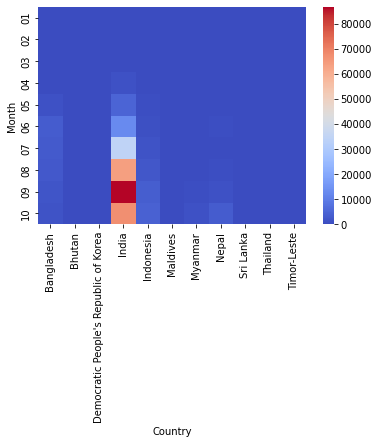

```python
Map_asia = sns.heatmap(heatMap, cmap='coolwarm')
```

[figure not shown]